# Analyze of World of Warcraft Battleground by Yiming Yang

## 0. Introduction

When I was in high school, I have played so much World of Warcraft. I love RPG game, and World of Warcraft is one of my favorite games. World of Warcraft is a massively multiplayer online role-playing game (MMORPG) released in 2004 by Blizzard Entertainment. After it came out, it became one of the most popular games. World of Warcraft was the world's most popular MMORPG by player count of nearly 10 million in 2009. It is the icon of MMORPG.

At the beginning, players will create their own character. They need to determine the class, which includes Death Knight, Demon Hunter, Druid, Hunter, Mage, Monk, Paladin, Priest, Rogue, Shaman, Warlock, and Warrior. Also, players need to determine their faction. There are two fractions, Horde and Alliance, and they are opposite.

Battlegrounds are instanced areas used for player versus player combat (PvP). In them players can participate in team PvP, struggling for victory in one of a number of battlegrounds against a similarly capable team of players from the opposite faction.

If you still want more information: Official website of WOW: https://worldofwarcraft.com/en-us/ This has everything you want to know about WOW(classes, faction, game mode): https://wow.gamepedia.com/Wowpedia More information about Battleground: https://wow.gamepedia.com/Battleground

In this tutorial, I will do an analyze on the winrate Battleground of World of Warcraft, which effect or determine the winrate. I will try to analyze if player's number of kills and deaths, damage and heal will effect the winrate, the winrate related to classes, faction, and maps. I will see if there is relationship between those.

## 1. Read the Data

We will use those libraries, pandas and numpy for data manipulation, matplotlib and seaborn for plot, sklearn and statsmodels for statistics and machine learning modeling.

```python
#libraries
import pandas as pd
import numpy as np
import matplotlib.pyplot as plt
import seaborn as sns
import sklearn
import statsmodels.api as sm
import statsmodels.formula.api as smf
from matplotlib.pyplot import figure
```

And then we will read the data, I find the data from Kaggle, which is the record and data of some random matches. In this dataset the meaning of columns are the following:

1. Battleground: The name of battleground or the map (AB: Arathi basin. - BG: Battle for Gilneas. - DG: Deepwind gorge. - ES: Eye of the storm. - SA: Strand of the ancients. - SM: Silvershard mines. - SS: Seething shore. - TK: Temple of Kotmogu. - TP: Twin peaks. - WG: Warsong gulch.)
2. Code: code for the battleground.
3. Faction: faction of the player (Horde or Alliance).
4. Class: class of the player (warrior, paladin, hunter, rogue, priest, death knight, shaman, mage, warlock, monk, druid, demon hunter).
5. KB: number of mortal kills given by the player.
6. D: number of times that the player died.
7. HK: number of killings where the player or his/her group contributed.
8. DD: damage done by the player.
9. HD: healing done by the player.
10. Honor: honor awarded to the player.
11. Win: 1 if the player won.
12. Lose: 1 if the player lost.
13. Rol: dps if the player is a damage dealer; heal if the player is focused in healing allies. Not all classes can be healers, just shaman, paladin, priest, monk and druid, but all classes can be damage dealers.
14. BE: some weeks there is a bonus event, when the honor gained is increased. 1 if the battleground happened during that week.

Therefore, we use pandas to read the data and display the head of the dataframe.

```python
#Read wowbgs.csv
df = pd.read_csv('wowbgs.csv')
print(df.head())
```

```
  Battleground Code   Faction         Class  KB  D  HK     DD     HD  Honor  \
0           WG  WG1     Horde        Hunter   1  3  14  48155   6641    532
1           WG  WG1     Horde  Death Knight   1  3  12  27025   7106    377
2           WG  WG1  Alliance       Paladin   0  1  19    824  93879    252
3           WG  WG1  Alliance       Paladin   1  2  25   7046  98599    274
4           WG  WG1  Alliance         Rogue   2  3  23  65483  19629    268

   Win  Lose   Rol  BE
0  1.0   NaN   dps NaN
1  1.0   NaN   dps NaN
2  NaN   1.0  heal NaN
3  NaN   1.0  heal NaN
4  NaN   1.0   dps NaN
```

## 1. Tidying the Data

Tidying data is to make data tidy, and we will be able to analyze on a clean data and a data ready to be used to plot or whatever. First, we will remove the columns(variables) that is not related to our topic, so I have removed

1. the code for battleground
2. Honor, this is the reward in the game, unrelated.
3. BE, bonus event, not related to winrate.

```python
#drop the columns
df=df.drop(columns=['Code','Honor','BE'])
df.head()
```

|  | Battleground | Faction | Class | KB | D | HK | DD | HD | Win | Lose | Rol |
| --- | --- | --- | --- | --- | --- | --- | --- | --- | --- | --- | --- |
| 0 | WG | Horde | Hunter | 1 | 3 | 14 | 48155 | 6641 | 1.0 | NaN | dps |
| 1 | WG | Horde | Death Knight | 1 | 3 | 12 | 27025 | 7106 | 1.0 | NaN | dps |
| 2 | WG | Alliance | Paladin | 0 | 1 | 19 | 824 | 93879 | NaN | 1.0 | heal |
| 3 | WG | Alliance | Paladin | 1 | 2 | 25 | 7046 | 98599 | NaN | 1.0 | heal |
| 4 | WG | Alliance | Rogue | 2 | 3 | 23 | 65483 | 19629 | NaN | 1.0 | dps |

Next, we need to deal with the NaN data. In this, NaN data only appears in Win and Lose, the NaN data means zero, so we fill them with 0. Also, we will use the ratio of KB to HK to see how much kills one contribute in team. Because sometimes there are lots of kills in a match, and sometimes there aren't lots of kills. The number of kills can't reflection the situation.

```python
#fill NaN with 0
df=df.fillna(0)
killratio_arr=[]

#calculate the kill ratio
for index, row in df.iterrows():
    if row['HK'] == 0:
        killratio_arr.append(0)
    else:
        temp=row['KB']/row['HK']
        killratio_arr.append(temp)
df['KR']=killratio_arr
print(df.head())
```

```
  Battleground   Faction         Class  KB  D  HK     DD     HD  Win  Lose  \
0           WG     Horde        Hunter   1  3  14  48155   6641  1.0   0.0
1           WG     Horde  Death Knight   1  3  12  27025   7106  1.0   0.0
2           WG  Alliance       Paladin   0  1  19    824  93879  0.0   1.0
3           WG  Alliance       Paladin   1  2  25   7046  98599  0.0   1.0
4           WG  Alliance         Rogue   2  3  23  65483  19629  0.0   1.0

    Rol        KR
0   dps  0.071429
1   dps  0.083333
2  heal  0.000000
3  heal  0.040000
4   dps  0.086957
```

After this, our data is tidy now. We will do an EDA then.

## 2. Exploratory Data Analysis

### Winrate for different Faction

We have two factions in WOW, Horde and Alliance. Now, we will see which faction wins more, or the winrate of the two factions.

```python
#Group by faction and sum the number of wins and loses.
df_faction=df.groupby('Faction').sum()
df_faction=df_faction.drop(columns=['KB','D','DD','HD','HK','KR'])
print(df_faction)
```

```
             Win    Lose
Faction
Alliance   645.0  1206.0
Horde     1244.0   631.0
```

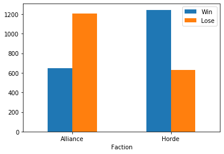

```python
#And we will plot the barplot
df_faction.plot.bar(rot=0)
plt.title('barplot for factions win and lose')
plt.show()
```

We can see from the dataframe and the plot. Horde has winrate of 1244/(1244+631)=66.3%, but Alliance has winrate of 645/(645+1206)=34.8%. Horde wins much more than (almost twice as) Alliance. It somehow means that if we choose Horde, we are more likely to win.

### Winrate vs Classes&Roles

We also want to check if winrate is related to classes and roles, so we will draw the barplot of different classes and roles.

```python
#Group by class
df_class=df.groupby('Class').sum()
```

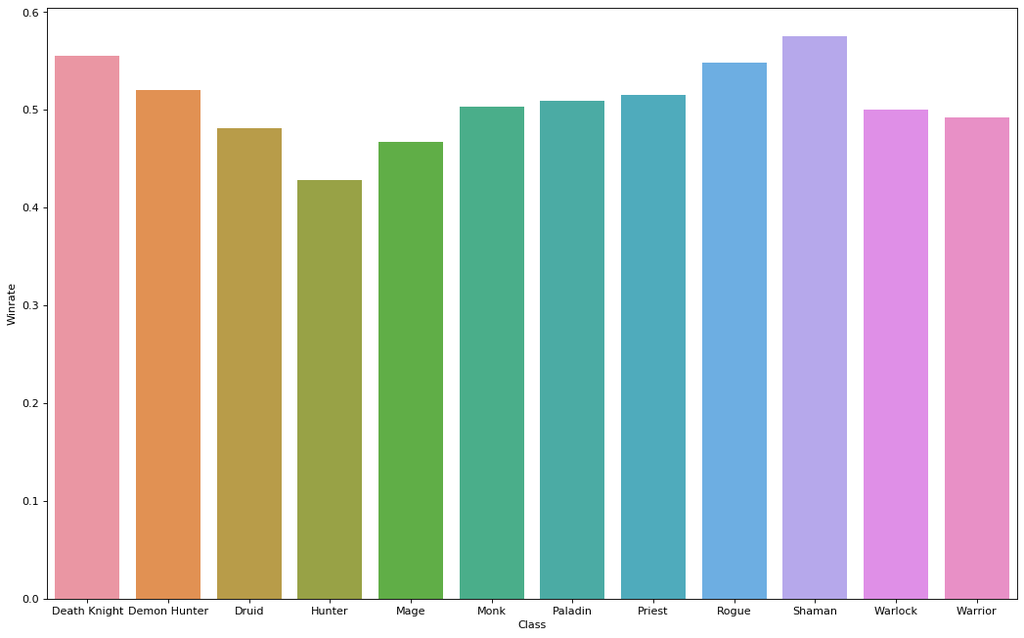

```python
#It will be more clear to calculate the winrate for each class
winrate_arr=[]
for index, row in df_class.iterrows():
    winrat=row['Win']/(row['Win']+row['Lose'])
    winrate_arr.append(winrat)
df_class['Winrate']=winrate_arr

#and we will plot the winrate and classes in a scatter plot
figure(num=None, figsize=(16, 10), dpi=80, facecolor='w', edgecolor='k')
sns.barplot(x=df_class.index, y='Winrate', data=df_class)
plt.title('barplot for classes winrate')
plt.show()
```

We get the result, we can see shaman has the highest winrate, the second is death knight, and the third is rogue. The class has the lowest winrate is Hunter. Therefore, when we create new character, if we want to have good performance in Battleground, we probably want to avoid choosing Hunter in Battleground.

```
         Win    Lose
Rol
dps   1507.0  1493.0
heal   382.0   344.0
```

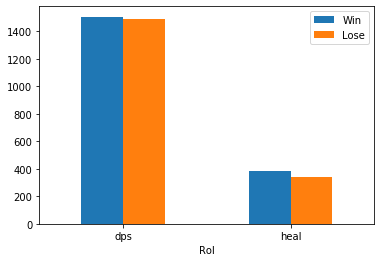

```python
#group by Rol and draw the bar plot
df_role=df.groupby('Rol').sum()
df_role=df_role.drop(columns=['KB','D','DD','HD','HK','KR'])
print(df_role)
df_role.plot.bar(rot=0)
plt.title('barplot for dps and heals win and lose')
plt.show()
```

We can see dps' winrate and heal's winrate are both around 50%, which is probably not a factor that effect winrate, so it doesn't matter if we choose dps or heal.

### Winrate vs Kill&Death and Damage&Heal

In this one we will use KD ratio and damage plus heal as our independent variables. First, like in other games, like League of Lengends has KDA ratio, here we use Kill and Death ratio, which is just KD ratio=kill/death, and we will graph it in a scatter plot.

```python
#create a new df for group by 'Battleground', 'Class', 'Rol'
df_map  = df.groupby(['Battleground', 'Class', 'Rol'], as_index=False)['KB', 'KR', 'HK','D', 'DD', 'HD', 'Win','Lose'].sum()
winrate_arr=[]
kd_arr=[]

#calculate and record winrate and kd rate
for index, row in df_map.iterrows():
    winrat=row['Win']/(row['Win']+row['Lose'])
    winrate_arr.append(winrat)
    kd=row['KB']/row['D']
    kd_arr.append(kd)
df_map['Winrate']=winrate_arr
df_map['KD']=kd_arr
df_map.head()
```

|  | Battleground | Class | Rol | KB | KR | HK | D | DD | HD | Win | Lose | Winrate | KD |
| --- | --- | --- | --- | --- | --- | --- | --- | --- | --- | --- | --- | --- | --- |
| 0 | AB | Death Knight | dps | 68 | 2.025478 | 506 | 49 | 1298463 | 473897 | 10.0 | 5.0 | 0.666667 | 1.387755 |
| 1 | AB | Demon Hunter | dps | 39 | 1.409925 | 458 | 52 | 800659 | 186962 | 9.0 | 7.0 | 0.562500 | 0.750000 |
| 2 | AB | Druid | dps | 84 | 2.804944 | 750 | 73 | 1152388 | 280533 | 15.0 | 9.0 | 0.625000 | 1.150685 |
| 3 | AB | Druid | heal | 2 | 0.095238 | 312 | 25 | 57543 | 948539 | 3.0 | 7.0 | 0.300000 | 0.080000 |
| 4 | AB | Hunter | dps | 33 | 1.476837 | 429 | 83 | 857920 | 157982 | 8.0 | 13.0 | 0.380952 | 0.397590 |

First, we will just see if the kill rate and team kill is related to winrate

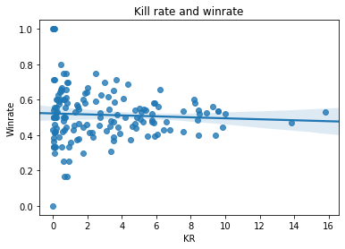

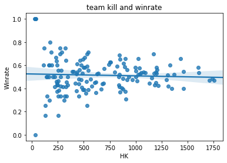

```python
#draw the linear regression for kr and team kill
sns.regplot(x="KR", y="Winrate",data=df_map)
plt.title('Kill rate and winrate')
plt.show()
sns.regplot(x="HK", y="Winrate",data=df_map)
plt.title('team kill and winrate')
plt.show()
```

It doesn't look like they are related. Then, we will plot the scatter plot for different role with different color of classes.

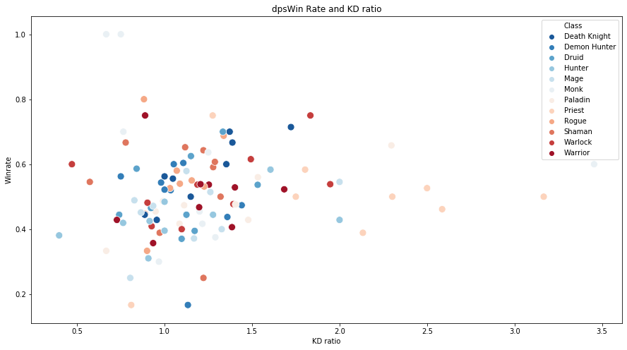

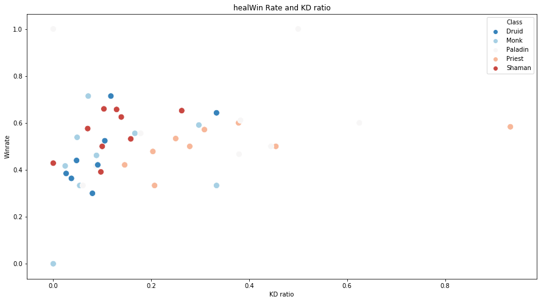

```python
#draw the graph of winrate and kd ratio
df_map_new=df_map.groupby('Rol')
for rol, table in df_map_new:
    if rol == 'dps':
        plt.figure(figsize=(15,8))
        sns.scatterplot(x="KD", y="Winrate",hue='Class',data=table, palette=sns.color_palette("RdBu_r", 12), s=100)
        plt.title(rol + 'Win Rate and KD ratio')
        plt.xlabel('KD ratio')
        plt.ylabel('Winrate')
    if rol == 'heal':
        plt.figure(figsize=(15,8))
        sns.scatterplot(x="KD", y="Winrate",hue='Class',data=table, palette=sns.color_palette("RdBu_r", 5), s=100)
        plt.title(rol + 'Win Rate and KD ratio')
        plt.xlabel('KD ratio')
        plt.ylabel('Winrate')
plt.show()
```

Therefore, by looking at the graph, it doesn't look like when KD ratio is higher, the winrate is higher for both dps and heal. Then, we will check if the damage dealt by dps and heal by healer is related to winrate

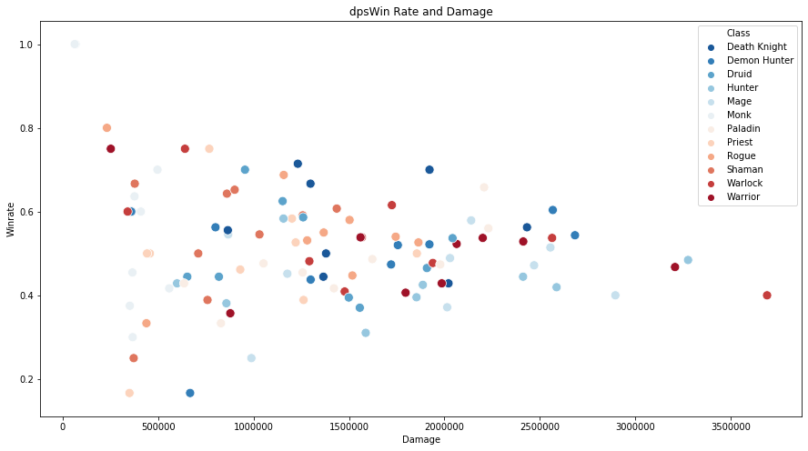

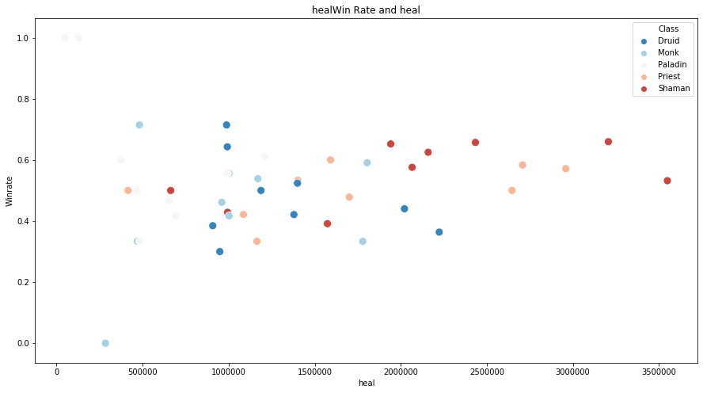

```python
#draw the graph of winrate and damage and heal
for rol, table in df_map_new:
    if rol == 'dps':
        plt.figure(figsize=(15,8))
        sns.scatterplot(x="DD", y="Winrate",hue='Class',data=table, palette=sns.color_palette("RdBu_r", 12), s=100)
        plt.title(rol + 'Win Rate and Damage')
        plt.xlabel('Damage')
        plt.ylabel('Winrate')
    if rol == 'heal':
        plt.figure(figsize=(15,8))
        sns.scatterplot(x="HD", y="Winrate",hue='Class',data=table, palette=sns.color_palette("RdBu_r", 5), s=100)
        plt.title(rol + 'Win Rate and heal')
        plt.xlabel('heal')
        plt.ylabel('Winrate')
plt.show()
```

For the relationship between damage dealt by dps and winrate, it doesn't look like there is relationship. When damage is low, different calss can still have different winrate. However, I am not sure about the heal by healer and winrate, it looks like it has a little bit relationship. We will do a statistic analysis in the next part.

Then what if we try to see the heal by dps and damage by healer's winrate?

[figure not shown]

[figure not shown]

```python
#draw the graph of winrate and damage and heal
for rol, table in df_map_new:
    if rol == 'dps':
        plt.figure(figsize=(15,8))
        sns.scatterplot(x="HD", y="Winrate",hue='Class',data=table, palette=sns.color_palette("RdBu_r", 12), s=100)
        plt.title(rol + 'Win Rate and heal')
        plt.xlabel('Damage')
        plt.ylabel('Winrate')
    if rol == 'heal':
        plt.figure(figsize=(15,8))
        sns.scatterplot(x="DD", y="Winrate",hue='Class',data=table, palette=sns.color_palette("RdBu_r", 5), s=100)
        plt.title(rol + 'Win Rate and damage')
        plt.xlabel('heal')
        plt.ylabel('Winrate')
plt.show()
```

Again, it doesn't look like dps' anything is related to winrate. However, it looks like healer's damage is probably related to winrate.

In conclusion, the healer's heal and damage may effect the winrate, but probably we can't determine winrate by just looking at kill rate, KD ratio, and the number of damage and heal from dps.

### Winrate in different maps

In this section, we will check in different map, the performance of different classes and different factions's winrate. We will use heatmap for this because heatmap is a pretty good visualiztion for two categorical variables.

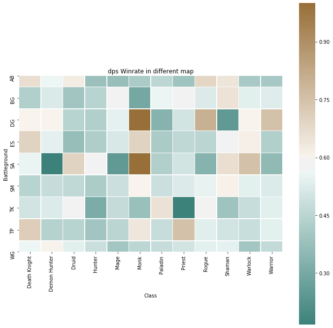

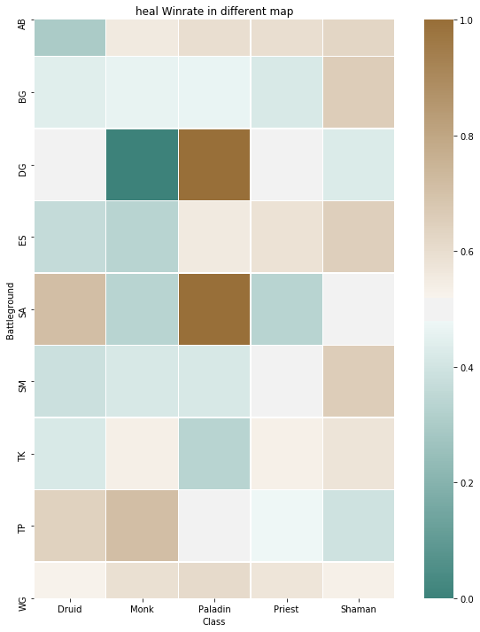

```python
#draw the heatmap
df_map_new=df_map.groupby('Rol')

cmap = sns.diverging_palette(180,50, as_cmap=True)
for rol, table in df_map_new:
    pivot = table.pivot(index='Battleground', columns='Class', values='Winrate')
    f, ax = plt.subplots(figsize=(12,12))
    plt.title(rol + ' Winrate in different map')
    sns.heatmap(pivot, cmap=cmap, square=True, linewidths=.5, ax=ax)
plt.show()
```

From the heat map, we find that as a dps role, Monk has won a lot in battleground SA and DG. As a heal role, Paladin wins a lot in SA and DG. One reason is probably, they are at the same team at those matches. We can probably say that paladin and Monk is a very good comp in battleground SA and DG. Or maybe their matches are just too few, so the color can't reflect their overall strength.

Also, for dps, Rogue is pretty good in DG. Death knight and priest good in TP, warlock good in SA, and warrior good in DG. For healer, Monk is good in TP, too. Druid is good in SA and TP. Shaman is good in SM, ES, BG. Moreover, by just looking at the color. The heatmap of heal has more brown than dps. We can say heal are more likely to win.

For, our EDA analysis, it looks like KD ratio, KR, damage and heal from dps is not related to winrate. Heal's damage and heal is probably related to winrate, and heal wins more than dps, which means heal may be more likely to win battleground. Moreover, Horde is more likely to win. Shaman has the highest winrate, and hunter has the lowest.

## 3. Predict the winrate

Here we will use the factors that we think is related to the winrate in statistics, and we will try to set a linear regression model for them and see if we can use those variables to predict the winrate.

First, we will see if there's KD and winrate is correlated.

```python
#fit in linear regression model and get the summary
X=df_map['KD']
Y=df_map['Winrate']
X = sm.add_constant(X)
model = sm.OLS(Y, X).fit()
predictions = model.predict(X)
print_model = model.summary()
print(print_model)
```

```
                            OLS Regression Results
==============================================================================
Dep. Variable:                Winrate   R-squared:                       0.004
Model:                            OLS   Adj. R-squared:                 -0.002
Method:                 Least Squares   F-statistic:                    0.6336
Date:                Mon, 16 Dec 2019   Prob (F-statistic):              0.427
Time:                        15:08:55   Log-Likelihood:                 78.165
No. Observations:                 153   AIC:                            -152.3
Df Residuals:                     151   BIC:                            -146.3
Df Model:                           1
Covariance Type:            nonrobust
==============================================================================
                 coef    std err          t      P>|t|      [0.025      0.975]
------------------------------------------------------------------------------
const          0.5006      0.021     23.904      0.000       0.459       0.542
KD             0.0148      0.019      0.796      0.427      -0.022       0.052
==============================================================================
Omnibus:                       22.406   Durbin-Watson:                   2.253
Prob(Omnibus):                  0.000   Jarque-Bera (JB):               53.374
Skew:                           0.584   Prob(JB):                     2.57e-12
Kurtosis:                       5.647   Cond. No.                         3.26
==============================================================================

Warnings:
[1] Standard Errors assume that the covariance matrix of the errors is correctly specified.
```

Therefore, since it has very big p value. We would reject our hypothesis that they are correlated. Then, we will look at the correlation between winrate and Kill rate, damage, heal.

```python
#fit in linear regression model and get the summary
X=df_map['KR']
Y=df_map['Winrate']
X = sm.add_constant(X)
model = sm.OLS(Y, X).fit()
predictions = model.predict(X)
print_model = model.summary()
print(print_model)
```

```
                            OLS Regression Results
==============================================================================
Dep. Variable:                Winrate   R-squared:                       0.003
Model:                            OLS   Adj. R-squared:                 -0.003
Method:                 Least Squares   F-statistic:                    0.5165
Date:                Mon, 16 Dec 2019   Prob (F-statistic):              0.473
Time:                        15:08:59   Log-Likelihood:                 78.106
No. Observations:                 153   AIC:                            -152.2
Df Residuals:                     151   BIC:                            -146.2
Df Model:                           1
Covariance Type:            nonrobust
==============================================================================
                 coef    std err          t      P>|t|      [0.025      0.975]
------------------------------------------------------------------------------
const          0.5224      0.016     32.151      0.000       0.490       0.555
KR            -0.0027      0.004     -0.719      0.473      -0.010       0.005
==============================================================================
Omnibus:                       17.447   Durbin-Watson:                   2.230
Prob(Omnibus):                  0.000   Jarque-Bera (JB):               43.285
Skew:                           0.406   Prob(JB):                     3.99e-10
Kurtosis:                       5.476   Cond. No.                         6.01
==============================================================================

Warnings:
[1] Standard Errors assume that the covariance matrix of the errors is correctly specified.
```

```python
#fit in linear regression model and get the summary
X=df_map['DD']
Y=df_map['Winrate']
X = sm.add_constant(X)
model = sm.OLS(Y, X).fit()
predictions = model.predict(X)
print_model = model.summary()
print(print_model)
```

```
                            OLS Regression Results
==============================================================================
Dep. Variable:                Winrate   R-squared:                       0.009
Model:                            OLS   Adj. R-squared:                  0.002
Method:                 Least Squares   F-statistic:                     1.322
Date:                Mon, 16 Dec 2019   Prob (F-statistic):              0.252
Time:                        15:09:01   Log-Likelihood:                 78.511
No. Observations:                 153   AIC:                            -153.0
Df Residuals:                     151   BIC:                            -147.0
Df Model:                           1
Covariance Type:            nonrobust
==============================================================================
                 coef    std err          t      P>|t|      [0.025      0.975]
------------------------------------------------------------------------------
const          0.5303      0.018     29.178      0.000       0.494       0.566
DD         -1.585e-08   1.38e-08     -1.150      0.252   -4.31e-08    1.14e-08
==============================================================================
Omnibus:                       15.958   Durbin-Watson:                   2.230
Prob(Omnibus):                  0.000   Jarque-Bera (JB):               40.611
Skew:                           0.338   Prob(JB):                     1.52e-09
Kurtosis:                       5.432   Cond. No.                     2.03e+06
==============================================================================

Warnings:
[1] Standard Errors assume that the covariance matrix of the errors is correctly specified.
[2] The condition number is large, 2.03e+06. This might indicate that there are
strong multicollinearity or other numerical problems.
```

```python
#fit in linear regression model and get the summary
X=df_map['HD']
Y=df_map['Winrate']
X = sm.add_constant(X)
model = sm.OLS(Y, X).fit()
predictions = model.predict(X)
print_model = model.summary()
print(print_model)
```

```
                            OLS Regression Results
==============================================================================
Dep. Variable:                Winrate   R-squared:                       0.000
Model:                            OLS   Adj. R-squared:                 -0.007
Method:                 Least Squares   F-statistic:                  0.001254
Date:                Mon, 16 Dec 2019   Prob (F-statistic):              0.972
Time:                        15:28:27   Log-Likelihood:                 77.845
No. Observations:                 153   AIC:                            -151.7
Df Residuals:                     151   BIC:                            -145.6
Df Model:                           1
Covariance Type:            nonrobust
==============================================================================
                 coef    std err          t      P>|t|      [0.025      0.975]
------------------------------------------------------------------------------
const          0.5140      0.016     31.279      0.000       0.482       0.546
HD          6.271e-10   1.77e-08      0.035      0.972   -3.44e-08    3.56e-08
==============================================================================
Omnibus:                       20.149   Durbin-Watson:                   2.226
Prob(Omnibus):                  0.000   Jarque-Bera (JB):               48.163
Skew:                           0.512   Prob(JB):                     3.48e-11
Kurtosis:                       5.551   Cond. No.                     1.29e+06
==============================================================================

Warnings:
[1] Standard Errors assume that the covariance matrix of the errors is correctly specified.
[2] The condition number is large, 1.29e+06. This might indicate that there are
strong multicollinearity or other numerical problems.
```

For those, all the p values are > 0.05. Therefore, they are also not correlated. Since, by our EDA above, heal and classes may play an important role, so we will try to find a model that has interaction terms.

```python
#fit in linear regression model and get the summary
res = smf.ols(formula='Winrate ~ KD + DD + HD + C(Rol) + DD*C(Rol) + HD*C(Rol) +C(Class)', data=df_map).fit()
print(res.summary())
```

```
                            OLS Regression Results
==============================================================================
Dep. Variable:                Winrate   R-squared:                       0.149
Model:                            OLS   Adj. R-squared:                  0.042
Method:                 Least Squares   F-statistic:                     1.390
Date:                Mon, 16 Dec 2019   Prob (F-statistic):              0.151
Time:                        15:11:15   Log-Likelihood:                 90.185
No. Observations:                 153   AIC:                            -144.4
Df Residuals:                     135   BIC:                            -89.82
Df Model:                          17
Covariance Type:            nonrobust
============================================================================================
                               coef    std err          t      P>|t|      [0.025      0.975]
--------------------------------------------------------------------------------------------
Intercept                    0.6042      0.077      7.854      0.000       0.452       0.756
C(Rol)[T.heal]               0.0385      0.068      0.570      0.569      -0.095       0.172
C(Class)[T.Demon Hunter]    -0.1659      0.087     -1.908      0.059      -0.338       0.006
C(Class)[T.Druid]           -0.1171      0.074     -1.572      0.118      -0.264       0.030
C(Class)[T.Hunter]          -0.2497      0.099     -2.531      0.013      -0.445      -0.055
C(Class)[T.Mage]            -0.2038      0.089     -2.290      0.024      -0.380      -0.028
C(Class)[T.Monk]            -0.0943      0.069     -1.369      0.173      -0.231       0.042
C(Class)[T.Paladin]         -0.0842      0.066     -1.278      0.203      -0.214       0.046
C(Class)[T.Priest]          -0.2091      0.072     -2.899      0.004      -0.352      -0.066
C(Class)[T.Rogue]           -0.0976      0.083     -1.173      0.243      -0.262       0.067
C(Class)[T.Shaman]          -0.1175      0.074     -1.586      0.115      -0.264       0.029
C(Class)[T.Warlock]         -0.0175      0.069     -0.256      0.799      -0.153       0.118
C(Class)[T.Warrior]         -0.1434      0.084     -1.708      0.090      -0.309       0.023
KD                           0.0512      0.031      1.657      0.100      -0.010       0.112
DD                        5.429e-08   5.08e-08      1.069      0.287   -4.62e-08    1.55e-07
DD:C(Rol)[T.heal]         7.966e-07   3.57e-07      2.230      0.027    9.02e-08     1.5e-06
HD                       -2.916e-07   1.73e-07     -1.681      0.095   -6.35e-07    5.15e-08
HD:C(Rol)[T.heal]         1.911e-07    1.9e-07      1.003      0.318   -1.86e-07    5.68e-07
==============================================================================
Omnibus:                       19.083   Durbin-Watson:                   2.384
Prob(Omnibus):                  0.000   Jarque-Bera (JB):               64.090
Skew:                           0.317   Prob(JB):                     1.21e-14
Kurtosis:                       6.107   Cond. No.                     2.83e+07
==============================================================================

Warnings:
[1] Standard Errors assume that the covariance matrix of the errors is correctly specified.
[2] The condition number is large, 2.83e+07. This might indicate that there are
strong multicollinearity or other numerical problems.
```

Although it is better than the previous, most of its p values are still > 0.05. Therefore, by looking at the new statistics, the new p values, if we use 0.05 as our criteria, only the term hunter, Mage, Priest, and the term damage*heal has p value < 0.05, so we can't say we can use those values to predict the winrate. It's seems that we can't use those variables to predict the winrate.